# Lab week 2 - Stacking

Data Science and Machine Learning 3 - CEU 2019

Jeno Pal

2019-02-25

```r
library(data.table)
library(GGally)
library(h2o)
h2o.init(max_mem_size = '6g')
```

[output not shown]

Stacking:

- specify different $L$ predictive models
- score training observations using out-of-fold predictions
- this gives a “level-one” data: the original outcome and the scores coming from the $L$ base models
- use these to estimate a second level predictive model (“meta-learner”)

When predicting new observations

- the base models are estimated using all training observations, use these to get scores for the new observation
- input this to the meta-learner model to get the predicted outcome

The more uncorrelated predictions are, the more room there is to improve individual models.

Stacked models do not always perform better than individual ones but many times they do.

It is very convenient to create stacked ensembles in h2o, we are gaining practice with this now. See more [here](http://docs.h2o.ai/h2o/latest-stable/h2o-docs/data-science/stacked-ensembles.html).

```r
data <- h2o.importFile("../../data/airlines/airline100K.csv")
data_split <- h2o.splitFrame(data, ratios = 0.2, seed = 123)
data_train <- data_split[[1]]
data_test <- data_split[[2]]
y <- "dep_delayed_15min"
X <- setdiff(names(data_train), y)
```

Train some base learners using cross validation.

```r
glm_model <- h2o.glm(
  X, y,
  training_frame = data_train,
  family = "binomial",
  alpha = 1, # lasso model
  lambda_search = TRUE,
  seed = 123,
  nfolds = 5,
  keep_cross_validation_predictions = TRUE  # this is necessary to perform later stacking
)
```

```r
gbm_model <- h2o.gbm(
  X, y,
  training_frame = data_train,
  ntrees = 200,
  max_depth = 10,
  learn_rate = 0.1,
  seed = 123,
  nfolds = 5,
  keep_cross_validation_predictions = TRUE
)
```

```r
deeplearning_model <- h2o.deeplearning(
  X, y,
  training_frame = data_train,
  hidden = c(32, 8),
  seed = 123,
  nfolds = 5,
  keep_cross_validation_predictions = TRUE
)
```

```r
ensemble_model <- h2o.stackedEnsemble(
  X, y,
  training_frame = data_train,
  base_models = list(glm_model,
                     gbm_model,
                     deeplearning_model),
  keep_levelone_frame = TRUE)
```

```r
# we can look into the level-1 features that are used as features by the meta learner
level_1_features <- h2o.getFrame(ensemble_model@model$levelone_frame_id$name)
level_1_features
```

|  | GLM_model_R_1582730401132_1 | GBM_model_R_1582730401132_19 | DeepLearning_model_R_1582730401132_334 | dep_delayed_15min |
| --- | --- | --- | --- | --- |
| 1 | 0.40960732 | 9.601809e-01 | 0.42111582 | N |
| 2 | 0.15223891 | 1.630913e-03 | 0.17864680 | N |
| 3 | 0.19063988 | 1.888495e-03 | 0.11047278 | N |
| 4 | 0.27966615 | 2.751816e-02 | 0.23976525 | Y |
| 5 | 0.07150836 | 3.596214e-06 | 0.03899267 | N |
| 6 | 0.20053672 | 1.296405e-04 | 0.14368396 | Y |

```
[20063 rows x 4 columns]
```

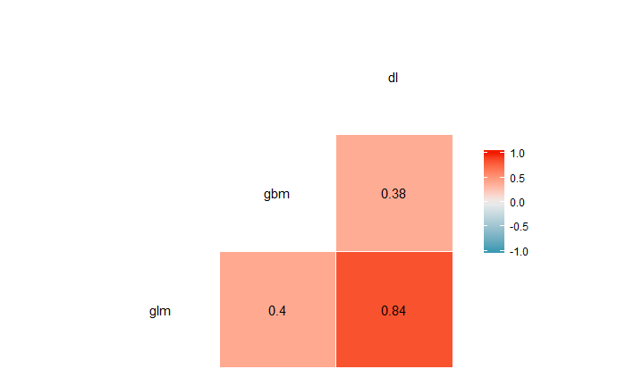

```r
# inspect correlations among scores from different models
level_1_dt <- as.data.table(level_1_features)[, 1:3]
setnames(level_1_dt, c("glm", "gbm", "dl"))
ggcorr(level_1_dt, label = TRUE, label_round = 2)
```

```r
# test set performances
print(h2o.auc(h2o.performance(glm_model, newdata = data_test)))
```

```
[1] 0.7026951
```

```r
print(h2o.auc(h2o.performance(gbm_model, newdata = data_test)))
```

```
[1] 0.6698799
```

```r
print(h2o.auc(h2o.performance(deeplearning_model, newdata = data_test)))
```

```
[1] 0.6848383
```

```r
# for the ensemble model
print(h2o.auc(h2o.performance(ensemble_model, newdata = data_test)))
```

```
[1] 0.7116373
```

The baseline meta-learner is a glm model. You can try others:

```r
ensemble_model_gbm <- h2o.stackedEnsemble(
  X, y,
  training_frame = data_train,
  metalearner_algorithm = "gbm",
  base_models = list(glm_model,
                     gbm_model,
                     deeplearning_model))
```

```r
print(h2o.auc(h2o.performance(ensemble_model_gbm, newdata = data_test)))
```

```
[1] 0.7109568
```

Meta-learning can also be built upon same-family, different hyperparameter models via a grid of hyperparameters.

```r
learn_rate_opt <- c(0.1, 0.3)
max_depth_opt <- c(3, 5, 7)
hyper_params <- list(learn_rate = learn_rate_opt,
                     max_depth = max_depth_opt)
gbm_grid <- h2o.grid(
  x = X, y = y,
  training_frame = data_train,
  algorithm = "gbm",
  ntrees = 10,
  hyper_params = hyper_params,
  seed = 123,
  nfolds = 5,
  keep_cross_validation_predictions = TRUE)
```

```r
ensemble_model_grid_gbm <- h2o.stackedEnsemble(
  X, y,
  training_frame = data_train,
  base_models = gbm_grid@model_ids)
```

```r
# individual test set performances
for (model_id in gbm_grid@model_ids) {
  model <- h2o.getModel(model_id)
  print(model_id)
  print(h2o.auc(h2o.performance(model, newdata = data_test)))
}
```

```
[1] "Grid_GBM_RTMP_sid_a267_6_model_R_1582730401132_434_model_2"
[1] 0.6908394
[1] "Grid_GBM_RTMP_sid_a267_6_model_R_1582730401132_434_model_1"
[1] 0.6952391
[1] "Grid_GBM_RTMP_sid_a267_6_model_R_1582730401132_434_model_3"
[1] 0.6867919
[1] "Grid_GBM_RTMP_sid_a267_6_model_R_1582730401132_434_model_5"
[1] 0.6746963
[1] "Grid_GBM_RTMP_sid_a267_6_model_R_1582730401132_434_model_4"
[1] 0.6808782
[1] "Grid_GBM_RTMP_sid_a267_6_model_R_1582730401132_434_model_6"
[1] 0.6642412
```

```r
print(h2o.auc(h2o.performance(ensemble_model_grid_gbm, newdata = data_test)))
```

```
[1] 0.699384
```

## AutoML

Based on stacking H2O offers an out-of-the-box tool called “auto ML”. It runs some models that differ from each other and then creates a stacked version of them. Finally, the best model is selectd.

```r
automl_model <- h2o.automl(X, y,
  training_frame = data_train,
  max_runtime_secs = 120)  # you can specify how long (approx.) you want the estimation to run
```

```
17:01:06.123: AutoML: XGBoost is not available; skipping it.
```

“Leaderboard” of the models: how well they perform based on cross-validation.

```r
lb <- automl_model@leaderboard
print(lb, n = nrow(lb))
```

|  | model_id | auc | logloss | aucpr | mean_per_class_error | rmse | mse |
| --- | --- | --- | --- | --- | --- | --- | --- |
| 1 | StackedEnsemble_AllModels_AutoML_20200226_170106 | 0.7164376 | 0.4424465 | 0.3794682 | 0.3471037 | 0.3739673 | 0.1398515 |
| 2 | StackedEnsemble_BestOfFamily_AutoML_20200226_170106 | 0.7142244 | 0.4431244 | 0.3771971 | 0.3459653 | 0.3741911 | 0.1400190 |
| 3 | GLM_1_AutoML_20200226_170106 | 0.7028257 | 0.4474568 | 0.3572755 | 0.3536922 | 0.3761843 | 0.1415146 |
| 4 | GBM_grid__1_AutoML_20200226_170106_model_3 | 0.6970010 | 0.4603108 | 0.3429774 | 0.3547279 | 0.3818120 | 0.1457804 |
| 5 | XRT_1_AutoML_20200226_170106 | 0.6938090 | 0.4585539 | 0.3658630 | 0.3651623 | 0.3789150 | 0.1435765 |
| 6 | GBM_grid__1_AutoML_20200226_170106_model_10 | 0.6932043 | 0.4515597 | 0.3424881 | 0.3555190 | 0.3782275 | 0.1430561 |
| 7 | DeepLearning_1_AutoML_20200226_170106 | 0.6922984 | 0.4542273 | 0.3472354 | 0.3607919 | 0.3789117 | 0.1435741 |
| 8 | GBM_grid__1_AutoML_20200226_170106_model_1 | 0.6894299 | 0.4636288 | 0.3371542 | 0.3605672 | 0.3832245 | 0.1468610 |
| 9 | GBM_1_AutoML_20200226_170106 | 0.6867573 | 0.4577960 | 0.3404193 | 0.3657487 | 0.3806306 | 0.1448797 |
| 10 | GBM_grid__1_AutoML_20200226_170106_model_6 | 0.6796074 | 0.4829849 | 0.3258721 | 0.3648120 | 0.3912481 | 0.1530751 |

[output cut: 13 more lines]

```
[23 rows x 7 columns]
```

```r
# the best performing model is stored in '@leader'
automl_model@leader
```

```
Model Details:
==============

H2OBinomialModel: stackedensemble
Model ID:  StackedEnsemble_AllModels_AutoML_20200226_170106
NULL


H2OBinomialMetrics: stackedensemble
** Reported on training data. **

MSE:  0.09661463
RMSE:  0.3108289
LogLoss:  0.3273047
Mean Per-Class Error:  0.1871292
AUC:  0.9180146
AUCPR:  0.7609149
Gini:  0.8360292

Confusion Matrix (vertical: actual; across: predicted) for F1-optimal threshold:
```

|  | N | Y | Error | Rate |
| --- | --- | --- | --- | --- |
| N | 14841 | 1388 | 0.085526 | =1388/16229 |
| Y | 1107 | 2727 | 0.288732 | =1107/3834 |
| Totals | 15948 | 4115 | 0.124358 | =2495/20063 |

```
Maximum Metrics: Maximum metrics at their respective thresholds
```

|  | metric | threshold | value | idx |
| --- | --- | --- | --- | --- |
| 1 | max f1 | 0.280394 | 0.686124 | 213 |
| 2 | max f2 | 0.195726 | 0.759743 | 267 |
| 3 | max f0point5 | 0.401417 | 0.718765 | 152 |
| 4 | max accuracy | 0.341019 | 0.883866 | 181 |
| 5 | max precision | 0.941164 | 1.000000 | 0 |
| 6 | max recall | 0.097826 | 1.000000 | 360 |
| 7 | max specificity | 0.941164 | 1.000000 | 0 |
| 8 | max absolute_mcc | 0.287749 | 0.609881 | 210 |
| 9 | max min_per_class_accuracy | 0.221167 | 0.831768 | 249 |
| 10 | max mean_per_class_accuracy | 0.212817 | 0.833847 | 255 |

[output cut: 8 more lines]

```
Gains/Lift Table: Extract with `h2o.gainsLift(<model>, <data>)` or `h2o.gainsLift(<model>, valid=<T/F>, xval=<T/F>)`

H2OBinomialMetrics: stackedensemble
** Reported on cross-validation data. **
** 5-fold cross-validation on training data (Metrics computed for combined holdout predictions) **

MSE:  0.1398515
RMSE:  0.3739673
LogLoss:  0.4424465
Mean Per-Class Error:  0.3471037
AUC:  0.7164376
AUCPR:  0.3794682
Gini:  0.4328752

Confusion Matrix (vertical: actual; across: predicted) for F1-optimal threshold:
```

|  | N | Y | Error | Rate |
| --- | --- | --- | --- | --- |
| N | 11456 | 4773 | 0.294103 | =4773/16229 |
| Y | 1534 | 2300 | 0.400104 | =1534/3834 |
| Totals | 12990 | 7073 | 0.314360 | =6307/20063 |

```
Maximum Metrics: Maximum metrics at their respective thresholds
```

|  | metric | threshold | value | idx |
| --- | --- | --- | --- | --- |
| 1 | max f1 | 0.191859 | 0.421748 | 264 |
| 2 | max f2 | 0.114999 | 0.586466 | 340 |
| 3 | max f0point5 | 0.297096 | 0.400308 | 184 |
| 4 | max accuracy | 0.569340 | 0.814135 | 64 |
| 5 | max precision | 0.917066 | 1.000000 | 0 |
| 6 | max recall | 0.062623 | 1.000000 | 399 |
| 7 | max specificity | 0.917066 | 1.000000 | 0 |
| 8 | max absolute_mcc | 0.267265 | 0.255318 | 205 |
| 9 | max min_per_class_accuracy | 0.176422 | 0.653886 | 278 |
| 10 | max mean_per_class_accuracy | 0.169689 | 0.656291 | 284 |

[output cut: 8 more lines]

```
Gains/Lift Table: Extract with `h2o.gainsLift(<model>, <data>)` or `h2o.gainsLift(<model>, valid=<T/F>, xval=<T/F>)`
```

```r
print(h2o.auc(h2o.performance(automl_model@leader, newdata = data_test)))
```

```
[1] 0.7210581
```

For a more in-depth tutorial, see [here](https://github.com/h2oai/h2o-tutorials/tree/master/h2o-world-2017/automl).